# Market Trends Judgement Model

- 0. Preparations: Libraries, Methods, and Functions
- 1. Introduction: Business Problem
- 2. Data
- 3. Method
- 4. Analysis
- 5. Results and Discussion
- 6. Conclusion

### 0. Preparations: Libraries, Methods, and Functions

```python
import requests
from bs4 import BeautifulSoup
import json
import pandas as pd
from datetime import datetime
import numpy as np
import matplotlib.pyplot as plt
import math
from scipy.stats import norm
from pathlib import *
import os.path
import string
from os.path import exists
```

```python
# Create a function to judge whether an array/list of date_string like "1/1/2023" is format"%m/%d/%Y" or not.
def is_mdY(date_array):
    min_len = min(13,len(date_array))
    splited = []
    for i in range(min_len):
        splited.append(date_array[i].split("/"))
    df = pd.DataFrame(splited,columns=["left","mid","year"])
    df.left = df.left.apply(lambda v:int(v.replace(",","").strip()))
    df.mid = df.mid.apply(lambda v:int(v.replace(",","").strip()))
    if (df.left > 12).sum() > 0:
#         print("The date format is '%d/%m/%Y'.")
        return False
    elif (df.mid > 12).sum() > 0:
#         print("The date format is '%m/%d/%Y'.")
        return True
    else:
        print("We can't judge whether the date format is '%m/%d/%Y' or '%d/%m/%Y'.")
```

```python
w_s = np.array(weight_same_rate(term_s))
w_m = np.array(weight_same_rate(term_m))
w_l = np.array(weight_same_rate(term_l))
```

```python
# create a batch_linear regression function, and output 27 numpy arrays / lists :
        # (6) b0, b1, i_predict, k_value, x_mean_2p_avg, y_mean_2p_avg,
        # (5) xy_mean_avg, y_p_mean_2p_avg, r_xy, sdv_y, r2,
        # (3) l_index_value_predict, sdv1_to_it_p, sdv1_over_it_p,
        # (5) sdv2_to_it_p, sdv2_over_it_p, sdv3_to_it_p, sdv3_over_it_p, index_value_predict
        # (3) amended_ln_index_value_predict, amended_sdv1_to_it_p, amended_sdv1_over_it_p,
        # (4) amended_sdv2_to_it_p, amended_sdv2_over_it_p, amended_sdv3_to_it_p, amended_sdv3_over_it_p,
        # (1) amended_index_value_predict
# All returns are numpy arrays.

def batch_linear(year_long, ln_index, index_first):
    year_long = np.array(year_long)
    ln_index = np.array(ln_index)
    b0 = np.array([])  # list of intercept of linear regression
    b1 = np.array([])  # list of slope of linear regression
    i_predict = np.array([])   # list of compound annual interest rate
    k_value = np.array([])  # list of k_value
    x_mean_2p_avg = np.array([])   # list of avg((x - x_mean)**2)
    y_mean_2p_avg = np.array([])   # list of avg((y - y_mean)**2)
    xy_mean_avg = np.array([])   # list of avg((x - x_mean)*(y-y_mean))
    y_p_mean_2p_avg = np.array([])   # list of avg((y_p - y_p_mean)**2)
    r_xy = np.array([])   # list of Correlation coefficient between ln(invest_value) and T
    sdv_y = np.array([])   # list of standard deviation of ln(invest_value)
    r2 = np.array([])   # list of R^2
    ln_index_predict = np.array([])   # list of predicted_ln(index_value)
    sdv1_to_it_p = np.array([])   # list of ( predicted_ln(index_value) - 1 * sdv_y )
    sdv1_over_it_p = np.array([])   # list of ( predicted_ln(index_value) + 1 * sdv_y )
    sdv2_to_it_p = np.array([])   # list of ( predicted_ln(index_value) - 2 * sdv_y )
    sdv2_over_it_p = np.array([])   # list of ( predicted_ln(index_value) + 2 * sdv_y )
    sdv3_to_it_p = np.array([])   # list of ( predicted_ln(index_value) - 3 * sdv_y )
    sdv3_over_it_p = np.array([])   # list of ( predicted_ln(index_value) + 3 * sdv_y )

    index_predict = np.array([])   # list of predicted_index_value

    # to batch linear regressions:
    sub_year_long = np.array([])
    sub_ln_index = np.array([])
    for num in range(len(year_long)):
        sub_year_long = np.append(sub_year_long,year_long[num])
        sub_ln_index = np.append(sub_ln_index,ln_index[num])
        if num <= 2:
            # Append np.nan to all the numpay arrays while index is not larger than 2.
            b0 = np.append(b0, np.nan)
            b1 = np.append(b1, np.nan)
            i_predict = np.append(i_predict, np.nan)
            k_value = np.append(k_value, np.nan)
            x_mean_2p_avg = np.append(x_mean_2p_avg, np.nan)
            y_mean_2p_avg = np.append(y_mean_2p_avg, np.nan)
            xy_mean_avg = np.append(xy_mean_avg, np.nan)
            y_p_mean_2p_avg = np.append(y_p_mean_2p_avg, np.nan)
            r_xy = np.append(r_xy, np.nan)
            sdv_y = np.append(sdv_y, np.nan)
            r2 = np.append(r2, np.nan)
            ln_index_predict = np.append(ln_index_predict, np.nan)
            sdv1_to_it_p = np.append(sdv1_to_it_p, np.nan)
            sdv1_over_it_p = np.append(sdv1_over_it_p, np.nan)
            sdv2_to_it_p = np.append(sdv2_to_it_p, np.nan)
            sdv2_over_it_p = np.append(sdv2_over_it_p, np.nan)
            sdv3_to_it_p = np.append(sdv3_to_it_p, np.nan)
            sdv3_over_it_p = np.append(sdv3_over_it_p, np.nan)
            index_predict = np.append(index_predict, np.nan)
        else:
            # Call function linear_one to get the values of all the variables:
            b0_num, b1_num, r_xy_num, sdv_y_num, r2_num, x_mean_2p_avg_num, y_mean_2p_avg_num,\
            xy_mean_avg_num, y_p_mean_2p_avg_num = linear_one(sub_year_long, sub_ln_index)
            # Append all the values of the variables to the appropriate numpay arrays.
            b0 = np.append(b0, b0_num)
            b1 = np.append(b1, b1_num)
            i_predict = np.append(i_predict, np.exp(b1_num) - 1)
            k_value = np.append(k_value, np.exp(b0_num))
            x_mean_2p_avg = np.append(x_mean_2p_avg, x_mean_2p_avg_num)
            y_mean_2p_avg = np.append(y_mean_2p_avg, y_mean_2p_avg_num)
            xy_mean_avg = np.append(xy_mean_avg, xy_mean_avg_num)
            y_p_mean_2p_avg = np.append(y_p_mean_2p_avg, y_p_mean_2p_avg_num)
            r_xy = np.append(r_xy, r_xy_num)
            sdv_y = np.append(sdv_y, sdv_y_num)
            r2 = np.append(r2, r2_num)
            ln_index_predict = np.append(ln_index_predict, b0_num + b1_num * year_long[num])
            sdv1_to_it_p = np.append(sdv1_to_it_p, ln_index_predict[num] - sdv_y_num)
            sdv1_over_it_p = np.append(sdv1_over_it_p, ln_index_predict[num] + sdv_y_num)
            sdv2_to_it_p = np.append(sdv2_to_it_p, ln_index_predict[num] - 2 * sdv_y_num)
            sdv2_over_it_p = np.append(sdv2_over_it_p, ln_index_predict[num] + 2 * sdv_y_num)
            sdv3_to_it_p = np.append(sdv3_to_it_p, ln_index_predict[num] - 3 * sdv_y_num)
            sdv3_over_it_p = np.append(sdv3_over_it_p, ln_index_predict[num] + 3 * sdv_y_num)
            index_predict = np.append(index_predict,\
                                np.exp(ln_index_predict[num]) * index_first)
            # print message to show how many runs has finished.
            if num % 1000 == 0:
                print(f"{datetime.now().strftime('%Y-%m-%d %H:%M:%S')}:We have just finished {num} runs. Please wait...")
            if num == (len(ln_index)-1):
                print(f"{datetime.now().strftime('%Y-%m-%d %H:%M:%S')}:We have just finished all {num+1} runs of the batch.")

    # Produce the amended numpy arrays.
    b0_last = b0[-1]
    b1_last = b1[-1]
    sdv_y_last = sdv_y[-1]
    amended_ln_index_predict = b0_last + b1_last * year_long
    amended_sdv1_to_it_p = amended_ln_index_predict - sdv_y_last
    amended_sdv1_over_it_p = amended_ln_index_predict + sdv_y_last
    amended_sdv2_to_it_p = amended_ln_index_predict - 2 * sdv_y_last
    amended_sdv2_over_it_p = amended_ln_index_predict + 2 * sdv_y_last
    amended_sdv3_to_it_p = amended_ln_index_predict - 3 * sdv_y_last
    amended_sdv3_over_it_p = amended_ln_index_predict + 3 * sdv_y_last
    amended_index_predict = np.array([np.exp(item) * index_first for item in amended_ln_index_predict])

    return b0, b1, i_predict, k_value, x_mean_2p_avg, y_mean_2p_avg, xy_mean_avg, y_p_mean_2p_avg, r_xy, sdv_y, r2,\
ln_index_predict, sdv1_to_it_p, sdv1_over_it_p, sdv2_to_it_p, sdv2_over_it_p, sdv3_to_it_p, sdv3_over_it_p,\
index_predict,amended_ln_index_predict, amended_sdv1_to_it_p, amended_sdv1_over_it_p, amended_sdv2_to_it_p,\
amended_sdv2_over_it_p, amended_sdv3_to_it_p, amended_sdv3_over_it_p, amended_index_predict
```

### 1. Introduction: Business Problem

You may know a concept of time value of money which comes from money banking and investing theory. Time value of money means the return on an unit money in a unit time. In some sense, it is the same as interest rate.

Time value of money is determined by the base-interest-rate of central bank, economy, financial system, and so on.

Therefore, the time value of money is different at different stages.

The time value of money could be a key factor for us to make investing decisions. For example, if the time value of money at this stage is 2% or even lower than free-risk interest rate, do you want to invest?

We will try to divide the market into different stages reasonably and measure the time value of money in different stage.

What’s criteria or reasons for a reasonable division of different stages?

We think that there are different market trends among different stages, and there is no more than one steady trend in the same stage. So, if we can find out different steady market trends, we can get different stages, and we can easily measure the time value of money because it has the same meaning mathematically as the slope of the market trend.

That is why I call this porject a market trends judgement model(MTJM).

We hope that this project is valuable to potential investors and reserchers.

### 2. Data

We have two souces of data: "finance.yahoo.com" and "invest.com".

Because "invest.com" provides us a csv file where all the data is strings, we need to convert the strings to the appropriate types of data.

Since new data is generated almost every working day, this requires us to extract new data from "finance.yahoo.com" or "invest.com" website and write to this csv file.

Now, let's convert the data string to the appropriate data type and create a new csv file called "filename_converted.csv".

In this project, we use FTSE_100 as an example.

```python
original_file = "FTSE_100_Historical_Data.csv"
```

```python
# Create a function to transform the data of "investing.com" csv file from string to appropriate type.
def str_to_appr_investing_com(csv_file):
    df = pd.read_csv(csv_file)
    # In order to keep the columns consistent, we need rename the columns:
    df = df.rename(columns={"Vol.":"Volume","Change %":"Change"})
    # transform string to appropriate types of data:
    if is_mdY(df.Date):
        df.Date = df.Date.apply(lambda v: datetime.strptime(v,"%m/%d/%Y"))
    else:
        df.Date = df.Date.apply(lambda v: datetime.strptime(v,"%d/%m/%Y"))
    for column in ['Price', 'Open', 'High', 'Low']:
        df[column] = df[column].apply(lambda v: float(v.replace(",","").strip()))
    df.Volume = df.Volume.apply(string_BM_to_float)
    df.Change = df.Change.apply(string_percent_to_float)
    # sort by Date:
    df.sort_values("Date",inplace=True)
    df = df.groupby("Date").last()
    file_name = csv_file.split(".")[0]
    extension_name = "."+csv_file.split(".")[1]
    new_csv_file = file_name+"_Converted"+extension_name
    # create the new csv file:
    df.to_csv(new_csv_file,date_format="%Y/%m/%d")

# Create a function to transform the data of "finance.yahoo.com" csv file from string to appropriate type.
def str_to_appr_finance_yahoo(csv_file):
    df = pd.read_csv(csv_file)
    # In order to keep the columns consistent, we need to rename column "Adj Close**" to "Price"
    df = df.rename(columns={"Adj Close**":"Price","Close*":"Close"})
    # transform string to appropriate types of data:
    if is_mdY(df.Date):
        df.Date = df.Date.apply(lambda v: datetime.strptime(v,"%m/%d/%Y"))
    else:
        df.Date = df.Date.apply(lambda v: datetime.strptime(v,"%d/%m/%Y"))
    for column in ['Open', 'High', 'Low', 'Close', 'Price']:
        df[column] = df[column].apply(lambda v: float(v.replace(",","").strip()))
    df.Volume = df.Volume.apply(string_BM_to_float)
    # sort by Date:
    df.sort_values("Date",inplace=True)
    df = df.groupby("Date").last()
    file_name = csv_file.split(".")[0]
    extension_name = "."+csv_file.split(".")[1]
    new_csv_file = file_name+"_Converted"+extension_name
    # create the new csv file:
    df.to_csv(csv_file,date_format="%Y/%m/%d")
```

Because the orginal csv file of FTSE_100 comes from "investing.com", we call the funciotn str_to_appr_investing_com() and we will get a converted csv file:

```python
str_to_appr_investing_com(original_file)
```

In order to update the data, we need to scrape new data over the website.

```python
url = "https://www.investing.com/indices/uk-100-historical-data"
```

```python
# Create a function to scrape historical data from "investing.com"
# Return a pandas DataFrame.
def df_from_investing_com(url,header):
    response = requests.get(url,headers=header).text
    soup = BeautifulSoup(response, 'html.parser')
    tables = soup.find_all("table")
    table = tables[1].find_all('tr')
    columns = [table[0].find_all("th")[i].text for i in range(len(table[0].find_all("th")))]
    datas = []
    for i in range(1,len(table)):
        datas.append(
            [table[i].find_all("td")[j].text for j in range(len(table[i].find_all("td")))]
                   )
    df = pd.DataFrame(datas,columns=columns)
    # In order to keep the columns consistent, we need rename the columns:
    df = df.rename(columns={"Vol.":"Volume","Change %":"Change"})
    # transform string to appropriate types of data:
    df.Date = df.Date.apply(lambda v: datetime.strptime(v,"%m/%d/%Y"))
    for column in ['Price', 'Open', 'High', 'Low']:
        df[column] = df[column].apply(lambda v: float(v.replace(",","").strip()))

    df.Volume = df.Volume.apply(string_BM_to_float)
    df.Change = df.Change.apply(string_percent_to_float)
    # sort by Date:
    df.sort_values("Date",inplace=True)
    #reset index:
    df.reset_index(drop=True,inplace=True)
    return df

# Create a function to scrape historical data from "finance.yahoo.com"
# Return a pandas DataFrame.
def df_from_finance_yahoo(url,header):
    response = requests.get(url2,headers=header).text
    soup = BeautifulSoup(response,"html.parser")
    tables = soup.find_all('table')
    table = tables[0].find_all('tr')
    columns = [table[0].find_all('th')[i].text for i in range(len(table[0].find_all('th')))]
    datas = []
    for i in range(1,len(table)-1):
        datas.append(
            [table[i].find_all('td')[j].text for j in range(len(table[i].find_all('td')))]
        )
    # create DataFrame:
    df = pd.DataFrame(datas,columns=columns)
    # In order to keep the columns consistent, we need to rename column "Adj Close**" to "Price"
    df = df.rename(columns={"Adj Close**":"Price","Close*":"Close"})
    # transform string to appropriate types of data:
    df.Date = df.Date.apply(lambda v: datetime.strptime(v,"%b %d, %Y"))
    for column in ['Open', 'High', 'Low', 'Close', 'Price']:
        df[column] = df[column].apply(lambda v: float(v.replace(",","").strip()))
    df.Volume = df.Volume.apply(string_BM_to_float)
    # sort by Date:
    df.sort_values("Date",inplace=True)
    # reset index:
    df.reset_index(drop=True,inplace=True)
    return df
```

Because the new data of FTSE_100 comes from "invest.com", we use funtion df_from_investing_com() and we will get a pandas DataFrame with the new data:

```python
newdata_df = df_from_investing_com(url,header)
```

```python
newdata_df.tail()
```

|  | Date | Price | Open | High | Low | Volume | Change |
| --- | --- | --- | --- | --- | --- | --- | --- |
| 16 | 2023-05-26 | 7627.20 | 7570.87 | 7643.56 | 7556.92 | 6.875300e+08 | 0.0074 |
| 17 | 2023-05-30 | 7522.07 | 7627.20 | 7628.12 | 7516.52 | 8.377200e+08 | -0.0138 |
| 18 | 2023-05-31 | 7446.14 | 7522.07 | 7522.07 | 7446.14 | 2.280000e+09 | -0.0101 |
| 19 | 2023-06-01 | 7490.27 | 7446.14 | 7498.59 | 7445.30 | 9.626900e+08 | 0.0059 |
| 20 | 2023-06-02 | 7607.28 | 7490.27 | 7614.89 | 7490.02 | 6.326900e+08 | 0.0156 |

Now we are going to write the new data to the converted csv file.

```python
# Create a funtion to create or update the csv data file with the pandas DataFrame.
# Please note there is no return.
def create_update_csv(csv_file,df):
    if exists(csv_file):
        tem_df = pd.read_csv(csv_file)
        tem_df.Date = tem_df.Date.apply(lambda v: datetime.strptime(v,"%Y/%m/%d"))
        tem_df = tem_df.append(df,ignore_index=True)
        # delete the duplicated records:
        tem_df.sort_values('Date',inplace=True)
        tem_df = tem_df.groupby("Date").last()
        # reset index:
#         tem_df.reset_index(inplace=True)
        tem_df.to_csv(csv_file,date_format="%Y/%m/%d")
    else:
        # delete the duplicated records:
        df.sort_values('Date',inplace=True)
        df = df.groupby("Date").last()
        # reset index:
#         df.reset_index(inplace=True)
        df.to_csv(csv_file,date_format="%Y/%m/%d")
```

```python
data_file = "FTSE_100_Historical_Data_Converted.csv"
```

```python
create_update_csv(data_file,newdata_df)
```

Let's read the data from the csv file to a pandas DataFrame.

```python
df = pd.read_csv(data_file)
```

```python
df.tail()
```

|  | Date | Price | Open | High | Low | Volume | Change |
| --- | --- | --- | --- | --- | --- | --- | --- |
| 5654 | 2023/05/26 | 7627.20 | 7570.87 | 7643.56 | 7556.92 | 6.875300e+08 | 0.0074 |
| 5655 | 2023/05/30 | 7522.07 | 7627.20 | 7628.12 | 7516.52 | 8.377200e+08 | -0.0138 |
| 5656 | 2023/05/31 | 7446.14 | 7522.07 | 7522.07 | 7446.14 | 2.280000e+09 | -0.0101 |
| 5657 | 2023/06/01 | 7490.27 | 7446.14 | 7498.59 | 7445.30 | 9.626900e+08 | 0.0059 |
| 5658 | 2023/06/02 | 7607.28 | 7490.27 | 7614.89 | 7490.02 | 6.326900e+08 | 0.0156 |

```python
df.info()
```

```
<class 'pandas.core.frame.DataFrame'>
RangeIndex: 5659 entries, 0 to 5658
Data columns (total 7 columns):
 #   Column  Non-Null Count  Dtype
---  ------  --------------  -----
 0   Date    5659 non-null   object
 1   Price   5659 non-null   float64
 2   Open    5659 non-null   float64
 3   High    5659 non-null   float64
 4   Low     5659 non-null   float64
 5   Volume  5659 non-null   float64
 6   Change  5659 non-null   float64
dtypes: float64(6), object(1)
memory usage: 309.6+ KB
```

We notice that the type of "Date" is string, let's convert the type of "Date" from str to datetime.

```python
df.Date = df.Date.apply(lambda v: datetime.strptime(v, "%Y/%m/%d"))
```

```python
df.info()
```

```
<class 'pandas.core.frame.DataFrame'>
RangeIndex: 5659 entries, 0 to 5658
Data columns (total 7 columns):
 #   Column  Non-Null Count  Dtype
---  ------  --------------  -----
 0   Date    5659 non-null   datetime64[ns]
 1   Price   5659 non-null   float64
 2   Open    5659 non-null   float64
 3   High    5659 non-null   float64
 4   Low     5659 non-null   float64
 5   Volume  5659 non-null   float64
 6   Change  5659 non-null   float64
dtypes: datetime64[ns](1), float64(6)
memory usage: 309.6 KB
```

Now we begin to produce the datas for analysis:

```python
data_df = pd.DataFrame({"date":df.Date,
                       'price':df.index_price})
data_df.tail()
```

[output not shown]

```python
data_df.info()
```

```
<class 'pandas.core.frame.DataFrame'>
RangeIndex: 5659 entries, 0 to 5658
Data columns (total 2 columns):
 #   Column  Non-Null Count  Dtype
---  ------  --------------  -----
 0   date    5659 non-null   datetime64[ns]
 1   price   5659 non-null   float64
dtypes: datetime64[ns](1), float64(1)
memory usage: 88.5 KB
```

### 3. Method

A steady trend means that the error of the stage calculated by the model is small enough, or the model’s explanation is large enough. The trend is more steady, the model’s explanation is larger.

Here is an example of a steady trend.

[figure not shown]

We will use the model’s explanation as judging criteria:

a. If the model's explanation is large enough, there will be a steady trend. On the other hand, if the model's explanation is not large enough, there will be no a steady trend. We believe that the model's explanation should be at least greater than 65% to identify a steady trend. So, the model's explanation helps us to judge whether there is a steady trend.

b. When the modle's explanation of a steady trend decreases significantly, it signals a change in trend, although not necessarily a new trend. So, the decrease of the model's explanation helps us to determine if the trend has changed, in other words, when this stage(or this trend) ends, and when the new stage begins, although there might be no a new trend.

c. If we fine-tune the criteria, we will get a different market-stage-division. In our opinion, the maximium value of the total model's explanation implies the best division.

### 4. Analysis

We need to record the basispoint.

```python
first_date = data_df.date[0]
first_price = data_df.price[0]
first_year = first_date.year
date_0 = datetime(year=first_year, month=1, day=1)
first_day = (first_date - date_0).days / 365.25
```

We will calculate how long the date is to the first day.

```python
data_date = np.array(data_df.date)
date_delta = data_df.date - first_date
days_f = np.array(date_delta.apply(lambda v: v.days))
years = days_f / 365.25  # We suppose that there is 365.25 days in one year.
```

```python
price = np.array(data_df.price)
price_avg_s = avg_w_list(price, term_s)
price_avg_m = avg_w_list(price, term_m)
price_avg_l = avg_w_list(price, term_l)
```

```python
data_len = len(data_date)
data_len
```

```
5659
```

```python
i_d = [np.nan for _ in range(data_len)]
i_d[1:] = (price[1:] / first_price) ** (1 / days_f[1:]) - 1
i_d = np.array(i_d)

i_y = [np.nan for _ in range(data_len)]
i_y[1:] = (1+i_d[1:]) ** 365.25 -1
i_y = np.array(i_y)


ln_price = np.log(price / first_price)
ln_avg_s = np.log(price_avg_s / first_price)
ln_avg_m = np.log(price_avg_m / first_price)
ln_avg_l = np.log(price_avg_l / first_price)
```

Now, we have two data arrays: the time distance to the first day and the logarithm price. Let's observe the relationship tetween these two data arrays.

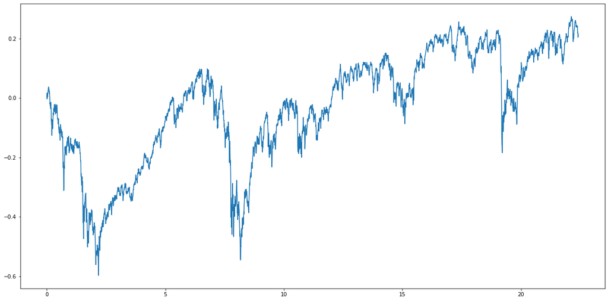

```python
fig,axs = plt.subplots(figsize=(20,10))
axs.plot(years,ln_price)
```

It looks like the two varibles are positively correlated and there might be a trend.

Let's batch linear regression and calculate the modle's explanations.

```python
b0_nseg, b1_nseg, i_predict_nseg, k_value_nseg, x_mean_2p_avg_nseg, y_mean_2p_avg_nseg, \
xy_mean_avg_nseg, y_p_mean_2p_avg_nseg, r_xy_nseg, sdv_y_nseg, r2_nseg, ln_price_predict_nseg, \
sdv1_to_it_p_nseg, sdv1_over_it_p_nseg, sdv2_to_it_p_nseg, sdv2_over_it_p_nseg, sdv3_to_it_p_nseg, \
sdv3_over_it_p_nseg, price_predict_nseg, amended_ln_price_predict_nseg, \
amended_sdv1_to_it_p_nseg, amended_sdv1_over_it_p_nseg, amended_sdv2_to_it_p_nseg, \
amended_sdv2_over_it_p_nseg, amended_sdv3_to_it_p_nseg, amended_sdv3_over_it_p_nseg, amended_price_predict_nseg,\
    = batch_linear(years, ln_price, first_price)
```

```
2023-06-03 13:28:01:We have just finished 1000 runs. Please wait...
2023-06-03 13:28:02:We have just finished 2000 runs. Please wait...
2023-06-03 13:28:02:We have just finished 3000 runs. Please wait...
2023-06-03 13:28:03:We have just finished 4000 runs. Please wait...
2023-06-03 13:28:04:We have just finished 5000 runs. Please wait...
2023-06-03 13:28:05:We have just finished all 5659 runs of the batch.
```

```python
df_nseg = pd.DataFrame({"year":data_date,
                       "ln_price":ln_price,
                       'ln_price_predict_nseg': ln_price_predict_nseg,
                       'sdv1_to_it_p_nseg': sdv1_to_it_p_nseg,
                       'sdv1_over_it_p_nseg': sdv1_over_it_p_nseg,
                       'sdv2_to_it_p_nseg': sdv2_to_it_p_nseg,
                       'sdv2_over_it_p_nseg': sdv2_over_it_p_nseg,
                       'sdv3_to_it_p_nseg': sdv3_to_it_p_nseg,
                       'sdv3_over_it_p_nseg': sdv3_over_it_p_nseg,
                       'amended_ln_price_predict_nseg': amended_ln_price_predict_nseg,
                       'amended_sdv1_to_it_p_nseg': amended_sdv1_to_it_p_nseg,
                       'amended_sdv1_over_it_p_nseg': amended_sdv1_over_it_p_nseg,
                       'amended_sdv2_to_it_p_nseg': amended_sdv2_to_it_p_nseg,
                       'amended_sdv2_over_it_p_nseg': amended_sdv2_over_it_p_nseg,
                       'amended_sdv3_to_it_p_nseg': amended_sdv3_to_it_p_nseg,
                       'amended_sdv3_over_it_p_nseg': amended_sdv3_over_it_p_nseg,})
df_nseg.columns
```

```
Index(['year', 'ln_price', 'ln_price_predict_nseg', 'sdv1_to_it_p_nseg',
       'sdv1_over_it_p_nseg', 'sdv2_to_it_p_nseg', 'sdv2_over_it_p_nseg',
       'sdv3_to_it_p_nseg', 'sdv3_over_it_p_nseg',
       'amended_ln_price_predict_nseg', 'amended_sdv1_to_it_p_nseg',
       'amended_sdv1_over_it_p_nseg', 'amended_sdv2_to_it_p_nseg',
       'amended_sdv2_over_it_p_nseg', 'amended_sdv3_to_it_p_nseg',
       'amended_sdv3_over_it_p_nseg'],
      dtype='object')
```

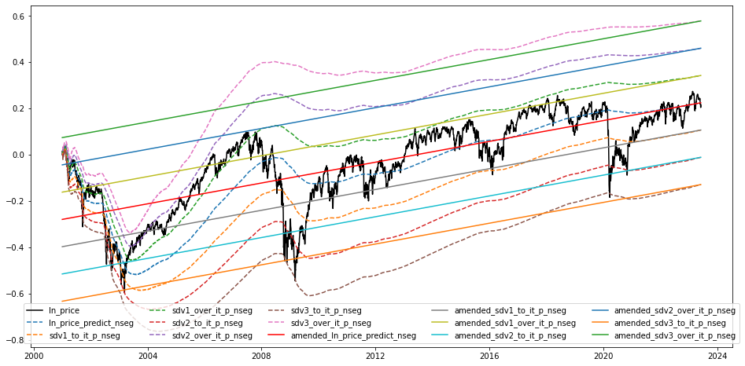

```python
fig,axs = plt.subplots(figsize=(16,8))
axs.plot(df_nseg.year,df_nseg.ln_price,"k-",label="ln_price")
for item in df_nseg.columns[2:9]:
    axs.plot(df_nseg.year,df_nseg[item],"--",label=item)
axs.plot(df_nseg.year,df_nseg.amended_ln_price_predict_nseg,"r",label="amended_ln_price_predict_nseg")
for item in df_nseg.columns[10:]:
    axs.plot(df_nseg.year,df_nseg[item],"-",label=item)
plt.legend(loc='lower center',ncol=5)
```

Let's observe the important varibles: the time value of money, the correlation coefficient, the standard var, and the model's explanation.

```python
print(f"i_predict_nseg = {i_predict_nseg[-1]}\nr_xy = {r_xy_nseg[-1]}\nsdv = {sdv_y_nseg[-1]}\nr2=  {r2_nseg[-1]}")
```

```
i_predict_nseg = 0.022753585882161254
r_xy = 0.7769980366490673
sdv = 0.11790588891434346
r2=  0.6037259489565053
```

```python
print(f"""The time value of money is {(i_predict_nseg[-1]*100):.2f}%.
The model's explanation r2 is {r2_nseg[-1]:.3f}, it is {'' if r2_nseg[-1]>=0.65 else 'not'} large enough to identify a steady trend.""")
print(f"{'' if r2_nseg[-1]>=0.65 else 'Was it a trend but has it changed?'}")
```

```
The time value of money is 2.28%.
The model's explanation r2 is 0.604, it is not large enough to identify a steady trend.
Was it a trend but has it changed?
```

Let's observe the maximum value of the model's explanations. We suppose that the shortest trend should last at least 500 dates.

```python
max(r2_nseg[499:])
```

```
0.8807914393153731
```

```python
print(f"The maximum of model's explanation is {max(r2_nseg[499:]):.3f}, which is {'' if max(r2_nseg[499:])>=0.65 else 'not'}large enough to confirm that there was at least a trend and has changed.")
```

```
The maximum of model's explanation is 0.881, which is large enough to confirm that there was at least a trend and has changed.
```

What will we find if we divide the market to different stages?

Can we get a best market-stage-division?

Let's try doing this.

```python
p_best = 0.7
q_best = -0.04
segments_r2_total_max = 0
p_list = []
q_list = []
segments_number_list = []
segments_first_date_list = []
segments_last_date_list = []
segments_r_xy_list = []
segments_xy_total_list = []
segments_sdv_list = []
segments_r2_list = []
segments_r2_total_list = []
segments_r2_total_exc_last_seg_list = []

# create the temperory best_seg_varies:
b0_seg_best = np.array([])
b1_seg_best = np.array([])
i_predict_seg_best = np.array([])
k_value_seg_best = np.array([])
x_mean_2p_avg_seg_best = np.array([])
y_mean_2p_avg_seg_best = np.array([])
xy_mean_avg_seg_best = np.array([])
y_p_mean_2p_avg_seg_best = np.array([])
r_xy_seg_best = np.array([])
sdv_y_seg_best = np.array([])
r2_seg_best = np.array([])
ln_price_predict_seg_best = np.array([])
sdv1_to_it_p_seg_best = np.array([])
sdv1_over_it_p_seg_best = np.array([])
sdv2_to_it_p_seg_best = np.array([])
sdv2_over_it_p_seg_best = np.array([])
sdv3_to_it_p_seg_best = np.array([])
sdv3_over_it_p_seg_best = np.array([])
price_predict_seg_best = np.array([])

amended_ln_price_predict_seg_best = np.array([])
amended_sdv1_to_it_p_seg_best = np.array([])
amended_sdv1_over_it_p_seg_best = np.array([])
amended_sdv2_to_it_p_seg_best = np.array([])
amended_sdv2_over_it_p_seg_best = np.array([])
amended_sdv3_to_it_p_seg_best = np.array([])
amended_sdv3_over_it_p_seg_best = np.array([])
amended_price_predict_seg_best = np.array([])

columns_seg_best = [b0_seg_best,
                    b1_seg_best,
                    i_predict_seg_best,
                    k_value_seg_best,
                    x_mean_2p_avg_seg_best,
                    y_mean_2p_avg_seg_best,
                    xy_mean_avg_seg_best,
                    y_p_mean_2p_avg_seg_best,
                    r_xy_seg_best,
                    sdv_y_seg_best,
                    r2_seg_best,
                    ln_price_predict_seg_best,
                    sdv1_to_it_p_seg_best,
                    sdv1_over_it_p_seg_best,
                    sdv2_to_it_p_seg_best,
                    sdv2_over_it_p_seg_best,
                    sdv3_to_it_p_seg_best,
                    sdv3_over_it_p_seg_best,
                    price_predict_seg_best,
                    amended_ln_price_predict_seg_best,
                    amended_sdv1_to_it_p_seg_best,
                    amended_sdv1_over_it_p_seg_best,
                    amended_sdv2_to_it_p_seg_best,
                    amended_sdv2_over_it_p_seg_best,
                    amended_sdv3_to_it_p_seg_best,
                    amended_sdv3_over_it_p_seg_best,
                    amended_price_predict_seg_best]

ave_r2_252_best = np.array([])
r2_change_explanation_power_best = np.array([])
segments_num_best = 1
segments_first_index_best = []
segments_last_index_best = []

segments_names_best = []
segments_from_date_best = []
segments_to_date_best = []
segments_price_best = []
segments_price_predict_best = []
segments_b0_best = []  # At last, we need to insert b0_nseg[-1] as the first element.
segments_b1_best = []  # At last, we need to insert b1_nseg[-1] as the first element.
segments_i_predict_best = []  # At last, we need to insert i_predict_nseg[-1] as the first element.
segments_k_value_best = []  # At last, we need to insert k_value_nseg[-1] as the first element.
segments_r_xy_best = []  # At last, we need to insert r_xy_nseg[-1] as the first element.
segments_sdv_best = []  # At last, we need to insert sdv_y_nseg[-1] as the first element.
segments_r2_best = []  # At last, we need to insert r2_nseg[-1] as the first element.


# we will calculate the following variables after the analysis.
segments_times_sdv_to_mean_best = []
# At last, we need to insert times_sdv_to_mean_nseg[-1] as the first element.
segments_probability_to_mean_best = []
# At last, we need to insert probability_to_mean_nseg[-1] as the first element.
segments_trading_signals_best = []
# At last, we need to insert trading_signals_nseg[-1] as the first element.

segments_xy_mean_avg_best = []
segments_x_mean_2p_avg_best = []
segments_y_mean_2p_avg_best = []
segments_y_p_mean_2p_avg_best = []
segments_var_best = []
segments_length_best = []
segments_len_percents_best = []
accu_segments_xy_mean_avg_best = 0
accu_segments_x_mean_2p_avg_best = 0
accu_segments_y_mean_2p_avg_best = 0
accu_segments_y_p_mean_2p_avg_best = 0
accu_segments_var_best = 0
segments_xy_total_best = 0
segments_sdv_total_best = 0
segments_r2_total_best = 0
```

```python
p_list.append(p_best)
q_list.append(q_best)
segments_number_list.append(segments_num_best)
segments_first_date_list.append(segments_first_index_best)
segments_last_date_list.append(segments_last_index_best)
segments_r_xy_list.append(segments_r_xy_best)
segments_xy_total_list.append(segments_xy_total_best)
segments_sdv_list.append(segments_sdv_best)
segments_r2_list.append(segments_r2_best)
segments_r2_total_list.append(segments_r2_total_best)
segments_r2_total_exc_last_seg_list.append(segments_r2_total_exc_last_seg_best)
pq_judge_df = pd.DataFrame({"p": p_list,
                            "q": q_list,
                            "segments_number": segments_number_list,
                            "segments_first_date": segments_first_date_list,
                            "segments_last_date": segments_last_date_list,
                            "segments_r_xy": segments_r_xy_list,
                            "segments_xy_total": segments_xy_total_list,
                            "segments_sdv": segments_sdv_list,
                            "segments_r2": segments_r2_list,
                            "segments_r2_total": segments_r2_total_list,
                            "segments_r2_total_exc_last_seg": segments_r2_total_exc_last_seg_list})
pq_judge_df
```

[output not shown]

66 rows × 11 columns

```python
segments_r2_best
```

```
[0.8280901213210995, 0.9632637124584348, 0.5209531282533496]
```

```python
print(f"We get the best market-stage-division with {segments_num_best} stages. \nThe model's explanations in these three stages are {segments_r2_best[0]:.3f}, {segments_r2_best[1]:.3f} and {segments_r2_best[2]:.3f}. ")
```

```
We get the best market-stage-division with 3 stages.
The model's explanations in these three stages are 0.828, 0.963 and 0.521.
```

```python
segments_first_index_best
```

```
[0, 671, 1741]
```

```python
segments_last_index_best
```

```
[670, 1740, 5658]
```

```python
print(f"The first stage is from {np.datetime_as_string(data_date[segments_first_index_best[0]],unit='D')} to {np.datetime_as_string(data_date[segments_last_index_best[0]],unit='D')}.")
print(f"The second stage is from {np.datetime_as_string(data_date[segments_first_index_best[1]],unit='D')} to {np.datetime_as_string(data_date[segments_last_index_best[1]],unit='D')}.")
print(f"The third stage is from {np.datetime_as_string(data_date[segments_first_index_best[2]],unit='D')} to {np.datetime_as_string(data_date[segments_last_index_best[2]],unit='D')}.")
```

```
The first stage is from 2001-01-03 to 2003-09-01.
The second stage is from 2003-09-02 to 2007-11-21.
The third stage is from 2007-11-22 to 2023-06-02.
```

Though the third stage lasts nearly 16 years, the model shows that there is no a steady trend in this stage until today.

Let's see the trends on the chart.

```python
df_seg = pd.DataFrame({"year":data_date,
                       "ln_price":ln_price,
                       'ln_price_predict_seg': ln_price_predict_seg_best,
                       'sdv1_to_it_p_seg': sdv1_to_it_p_seg_best,
                       'sdv1_over_it_p_seg': sdv1_over_it_p_seg_best,
                       'sdv2_to_it_p_seg': sdv2_to_it_p_seg_best,
                       'sdv2_over_it_p_seg': sdv2_over_it_p_seg_best,
                       'sdv3_to_it_p_seg': sdv3_to_it_p_seg_best,
                       'sdv3_over_it_p_seg': sdv3_over_it_p_seg_best,
                       'amended_ln_price_predict_seg': amended_ln_price_predict_seg_best,
                       'amended_sdv1_to_it_p_seg': amended_sdv1_to_it_p_seg_best,
                       'amended_sdv1_over_it_p_seg': amended_sdv1_over_it_p_seg_best,
                       'amended_sdv2_to_it_p_seg': amended_sdv2_to_it_p_seg_best,
                       'amended_sdv2_over_it_p_seg': amended_sdv2_over_it_p_seg_best,
                       'amended_sdv3_to_it_p_seg': amended_sdv3_to_it_p_seg_best,
                       'amended_sdv3_over_it_p_seg': amended_sdv3_over_it_p_seg_best,})
df_seg.columns
```

```
Index(['year', 'ln_price', 'ln_price_predict_seg', 'sdv1_to_it_p_seg',
       'sdv1_over_it_p_seg', 'sdv2_to_it_p_seg', 'sdv2_over_it_p_seg',
       'sdv3_to_it_p_seg', 'sdv3_over_it_p_seg',
       'amended_ln_price_predict_seg', 'amended_sdv1_to_it_p_seg',
       'amended_sdv1_over_it_p_seg', 'amended_sdv2_to_it_p_seg',
       'amended_sdv2_over_it_p_seg', 'amended_sdv3_to_it_p_seg',
       'amended_sdv3_over_it_p_seg'],
      dtype='object')
```

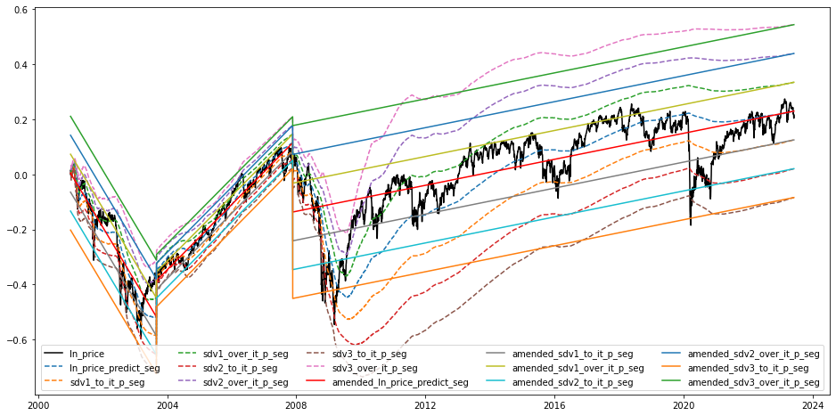

```python
fig,axs = plt.subplots(figsize=(16,8))
axs.plot(df_seg.year, df_seg.ln_price,'k-',label='ln_price')
for item in df_seg.columns[2:9]:
    axs.plot(df_seg.year,df_seg[item],"--",label=item)
axs.plot(df_seg.year, df_seg.amended_ln_price_predict_seg,'r-',label='amended_ln_price_predict_seg')
for item in df_seg.columns[10:]:
    axs.plot(df_seg.year,df_seg[item],"-",label=item)
plt.legend(loc='lower center',ncol=5)
```

```python
segments_i_predict_best
```

```
[-0.17817323131212737, 0.12597170375003497, 0.023890483891825243]
```

```python
print(f"The time value of money in these three stages are {(segments_i_predict_best[0]*100):.2f}%, {(segments_i_predict_best[1]*100):.2f}% and {(segments_i_predict_best[2]*100):.2f}%.")
```

```
The time value of money in these three stages are -17.82%, 12.60% and 2.39%.
```

Let's create a table to show the key variables.

```python
segments_names_best.append('Segment_accumulate')
segments_from_date_best.append(data_date[0])
segments_to_date_best.append(data_date[-1])
segments_price_best.append(np.nan)
segments_price_predict_best.append(np.nan)
segments_b0_best.append(np.nan)
segments_b1_best.append(np.nan)
segments_i_predict_best.append(np.nan)
segments_r_xy_best.append(segments_xy_total_best)
segments_sdv_best.append(segments_sdv_total_best)
segments_r2_best.append(segments_r2_total_exc_last_seg_best)

segments_names_best.insert(0, 'None_segment')  # At last, we need to insert 'None_segment' as the first element.
segments_from_date_best.insert(0, data_date[0])
segments_to_date_best.insert(0, data_date[-1])
segments_price_best.insert(0, price[-1])
segments_price_predict_best.insert(0, amended_price_predict_nseg[-1])
segments_b0_best.insert(0, b0_nseg[-1])  # At last, we need to insert b0_nseg[-1] as the first element.
segments_b1_best.insert(0, b1_nseg[-1])  # At last, we need to insert b1_nseg[-1] as the first element.
segments_i_predict_best.insert(0, i_predict_nseg[-1])
# At last, we need to insert i_predict_nseg[-1] as the first element.
segments_r_xy_best.insert(0, r_xy_nseg[-1])
# At last, we need to insert r_xy_nseg[-1] as the first element.
segments_sdv_best.insert(0, sdv_y_nseg[-1])
# At last, we need to insert sdv_y_nseg[-1] as the first element.
segments_r2_best.insert(0, r2_nseg[-1])
# At last, we need to insert r2_nseg[-1] as the first element.
```

```python
output_dic = {
    'segments_names': segments_names_best,
    'segments_from_date': segments_from_date_best,
    'segments_to_date': segments_to_date_best,
    'time_value_of_money':segments_i_predict_best,
    'segments_r_xy': segments_r_xy_best,
    'segments_sdv': segments_sdv_best,
    'segments_r2': segments_r2_best,
    }
```

```python
output_df = pd.DataFrame(output_dic)
```

```python
output_df
```

|  | segments_names | segments_from_date | segments_to_date | time_value_of_money | segments_r_xy | segments_sdv | segments_r2 |
| --- | --- | --- | --- | --- | --- | --- | --- |
| 0 | None_segment | 2001-01-03 | 2023-06-02 | 0.022754 | 0.776998 | 0.117906 | 0.603726 |
| 1 | segment 1 | 2001-01-03 | 2003-09-01 | -0.178173 | -0.909995 | 0.068859 | 0.828090 |
| 2 | segment 2 | 2003-09-02 | 2007-11-21 | 0.125972 | 0.981460 | 0.031659 | 0.963264 |
| 3 | segment 3 | 2007-11-22 | 2023-06-02 | 0.023890 | 0.721771 | 0.104644 | 0.520953 |
| 4 | Segment_accumulate | 2001-01-03 | 2023-06-02 | NaN | 0.621248 | 0.091270 | 0.910861 |

```python
stage_orders = ['The first stage','The second stage','The last stage']
print("="*110)
print("We divided the FTSE_100 to 3 stages:\n")
for item,i in zip(stage_orders,range(1,4)):
    print(f"{item} : {output_df.segments_from_date[i].strftime('%Y-%m-%d')} to {output_df.segments_to_date[i].strftime('%Y-%m-%d')}, time value of money is {(output_df.time_value_of_money[i]*100):.2f}%, model's explanation is {output_df.segments_r2[i]:.2f}.")
print(f"\n{'='*110}")
```

```
==============================================================================================================
We divided the FTSE_100 to 3 stages:

The first stage : 2001-01-03 to 2003-09-01, time value of money is -17.82%, model's explanation is 0.83.
The second stage : 2003-09-02 to 2007-11-21, time value of money is 12.60%, model's explanation is 0.96.
The last stage : 2007-11-22 to 2023-06-02, time value of money is 2.39%, model's explanation is 0.52.

==============================================================================================================
```

### 5. Results and Discussion

Our analysis shows that the FTSE_100 went through 3 stages from 2001-01-03 to 2023-06-02. We argue that there is a steady trend in each of the first two stages, but there is still no a steady trend in the last stage until today. And the time value of money in the last stage is 2.39%. In our opinion, FTSE_100 is not a good investing market today.

In fact, in addition to those most important information above, we can also get more from this project. For example, we calculated the predicted price, the exact position of the price to the predicted price under the assumption of normal distribution, and we can easily give investing signals with a function. However, this ofcourse does not mean that those investing signals are actually instructions for action, because we ignore some important factors such as changes in international and domestic political, economical and financial situation.

### 6. Conclusion

In this project, we developed a mothod to get the best market-stage-division, to judge if it is a steady trend, to calculate the time value of money in different stage. And we calculated the predicted price, even the investing signals if needed.

**We are just describing market stages and market trends, not explaining the reasons for the stages and trends.**

We hope this project will be valuable to potential long-term investors and market reserchers.

**Please note that the method of this project is only suitable for long-term investment in market indexes, not suitable for individual stocks and any short-term investment or even speculation.**